# Behind the rankings

A transparent workflow from large JSON files to restaurants, reviews, and official geographic areas.

Author

Brandon Lee

Published

October 29, 2026

Methods appendix · Full evidence and diagnostic maps

This appendix preserves the initial 672-restaurant descriptive pool and documents the later restriction to 656 restaurants inside Census New Orleans. Read the full results for the final top 15, reviewer-adjusted results, sensitivity analysis, and conclusions.

## Data and large-file handling

The business and review JSON streams were read in pages of 10,000 records. The complete review scan covered 6,990,280 records and retained 476,421 reviews for 2,259 New Orleans restaurant businesses. Category selection retained 672 businesses and 250,304 reviews; the independent city-boundary check produced the final 656-business, 249,002-review pool.

Only the fields needed for rating analysis were retained. Review text and voting fields were omitted, and filtered RDS files were saved so analysis could proceed without importing the raw JSON again. The filtered records are accumulated in memory before saving; this is not a fully disk-backed import.

The user reported that RStudio was unresponsive while handling the large data. Loading and verifying the smaller RDS files through a separate R process allowed work to continue without relying on the frozen session. No memory telemetry was collected, so the freeze’s cause is not established. Raw JSON and local review-level RDS files are excluded from Git; the repository contains derived results and code.

## Restaurant definition and theme

A business initially qualifies if its Yelp city is exactly `New Orleans`, its state is `LA`, and its comma-separated categories contain the exact `Restaurants` token. A match to any of **Cajun/Creole, Seafood, Southern, or Soul Food** then places it in the cooking theme. Each business counts once in the union. Both historical open and closed flags remain in diagnostic summaries; the final ranking adds the historical open-status and evidence rules described in the main report.

The label-based theme connects regional cooking traditions and seafood, but is broader than an authenticity definition. For example, a restaurant with a Seafood label can offer international cuisine. The initial city label also does not exhaust every business physically inside New Orleans: businesses labeled with another city were not recovered by that initial text filter.

## Initial descriptive results

The filtered theme contains **672 restaurants** and **250,304 reviews** from **138,848 distinct reviewers**. Reviews span **2005-03-14 to 2022-01-19**.

### Data quality

The missing-value audit found 0 NA values and 7 blank text fields. Details are shown below.

Duplicate-ID, review-linkage, rating-range, coordinate-range, date-parsing, and open-status checks found no issues. Range checks do not establish coordinate accuracy, and absence of missing values does not establish overall accuracy.

| Dataset | Column | NA values | Blank fields |
| --- | --- | --- | --- |
| restaurants | address | 0 | 7 |

The seven blank street addresses are retained because coordinates are present. They have not been imputed or independently checked; see the exported missing-address table for follow-up.

**435 businesses are marked open and 237 marked closed** in the historical snapshot. No open-status exclusion has been applied; these flags do not verify current operating status.

### Category counts and overlap

Memberships overlap: the four category counts must not be added together. Category means describe the included businesses; they are not independent cuisine comparisons.

| Category | Restaurants | Marked open | Mean stars | Median reviews | Total reviews |
| --- | --- | --- | --- | --- | --- |
| Cajun/Creole | 401 | 258 | 3.77 | 169.0 | 188,043 |
| Seafood | 331 | 235 | 3.87 | 117.0 | 144,026 |
| Southern | 155 | 98 | 3.91 | 174.0 | 66,355 |
| Soul Food | 70 | 47 | 3.96 | 44.5 | 16,936 |

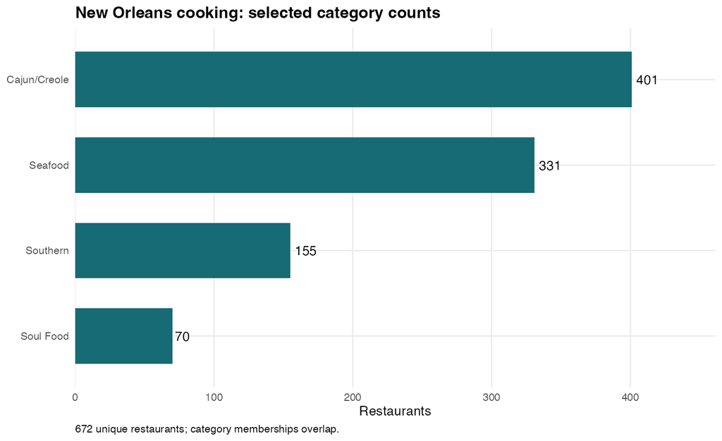

Restaurant counts for the four selected categories

### Ratings and review volume

| Measure | Min | Q1 | Median | Mean | Q3 | Max |
| --- | --- | --- | --- | --- | --- | --- |
| Yelp business stars | 1 | 3.50 | 4.00 | 3.82 | 4.00 | 5 |
| Available reviews per restaurant | 5 | 28.00 | 106.50 | 372.48 | 375.75 | 7,673 |
| Mean available review stars per restaurant | 1 | 3.54 | 3.94 | 3.83 | 4.21 | 5 |

Business stars are Yelp’s published business-level values. Mean review stars are recalculated from the available review records; they are separate measures. Each restaurant receives equal weight in the descriptive means above.

Available-review counts differ from the business table’s review_count for **473 restaurants**. Both counts are retained separately; threshold comparisons below use actual available review records. The cause of any differences has not been established.

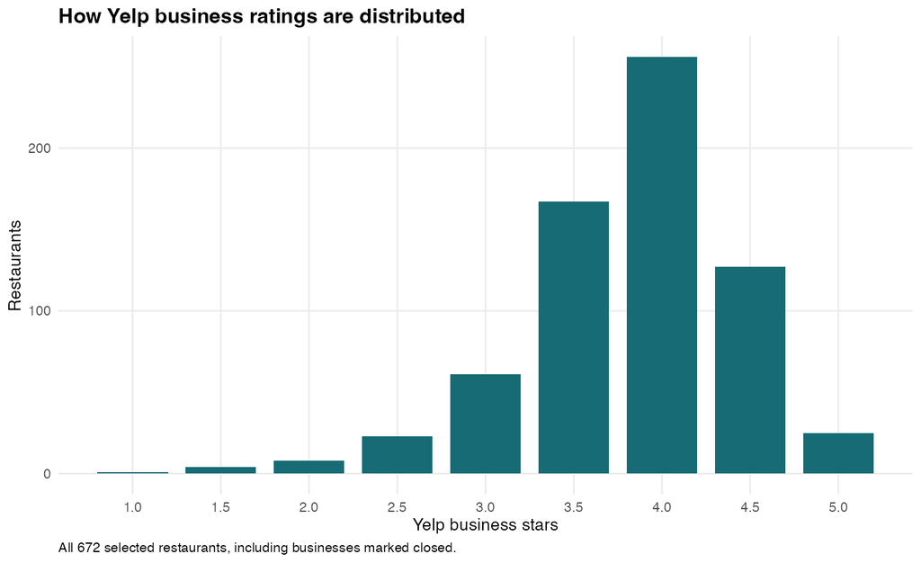

Distribution of Yelp business stars

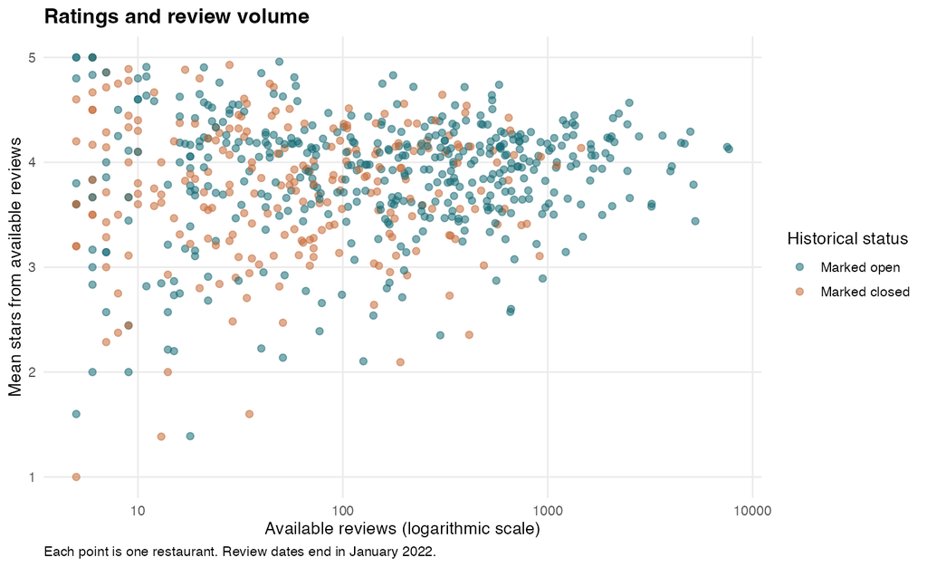

Restaurant average review stars versus available review volume

### Review-volume sensitivity

These are alternative eligibility rules, not a selected cutoff. The marked-open column shows how an additional historical open-status filter would change the pool.

| Min reviews | Restaurants | Marked open | Mean stars |
| --- | --- | --- | --- |
| 0 | 672 | 435 | 3.82 |
| 10 | 607 | 407 | 3.83 |
| 25 | 515 | 352 | 3.84 |
| 50 | 434 | 311 | 3.84 |
| 100 | 348 | 267 | 3.86 |

### Reviewer activity before normalization

Activity counts use reviews within the selected category group. This table shows how much data remains at different reviewer thresholds; the final reviewer-adjusted results appear in the main report.

| Min reviews per reviewer | Reviewers | Reviews retained | Reviews retained (%) |
| --- | --- | --- | --- |
| 1 | 138,848 | 250,304 | 100.00 |
| 3 | 21,971 | 109,647 | 43.81 |
| 5 | 7,123 | 60,254 | 24.07 |
| 10 | 1,395 | 25,527 | 10.20 |

### What remains

This initial section preserves the original 672-restaurant subset. The steps 3–6 section below completes the city-boundary and ZCTA/ward comparisons using the resulting 656 city-contained restaurants. The main report completes the eligibility rules, reviewer-adjusted scores, and top 15; these initial plots remain descriptive rather than final rankings.

## Steps 3–6: categories, joins, and geography

### Step 3: category evidence

The selected New Orleans cooking theme connects Cajun/Creole, seafood, Southern, and soul-food traditions. A restaurant qualifies by matching at least one selected category, rather than all four. The labels are an operational definition, not proof that every menu is uniquely local. Category memberships overlap.

The initial city-label subset contains 672 restaurants. After the explicit city-boundary check below, 656 restaurants remain in the geographic comparison:

| Category | Initial subset | Inside city |
| --- | --- | --- |
| Cajun/Creole | 401 | 398 |
| Seafood | 331 | 320 |
| Southern | 155 | 150 |
| Soul Food | 70 | 69 |

Co-occurrence among the 656 city-contained restaurants supports analyzing the labels together:

| Category 1 | Category 2 | Restaurants |
| --- | --- | --- |
| Cajun/Creole | Seafood | 155 |
| Cajun/Creole | Southern | 71 |
| Cajun/Creole | Soul Food | 30 |
| Seafood | Southern | 43 |
| Seafood | Soul Food | 19 |
| Southern | Soul Food | 18 |

The selected group occupies **17 ZCTAs and all 17 wards**. Both systems exceed the requirement of 10 restaurants across seven geographic areas. Category-by-area counts, average ratings, and review volumes are exported in category_by_area.csv.

### Step 4: businesses joined to reviews

Reviews were filtered before joining. An explicit many-to-one join on business_id attaches business names and categories to every selected review, preserving review IDs and the row count. The joined review-level RDS is saved locally as data/new_orleans/reviews_cooking_joined.rds; the smaller audit is committed.

| Check | Count |
| --- | --- |
| Selected restaurants | 672 |
| Reviews before join | 250,304 |
| Reviews after join | 250,304 |
| Unmatched review businesses | 0 |
| Duplicate review IDs after join | 0 |

The later city-only geographic subset contains **249,002 reviews** for 656 restaurants. The original 250,304-review subset is preserved; the new city-only RDS files are separate.

### Step 5: official city-boundary check

All 2,259 initial New Orleans restaurant locations were spatially joined to 2020 Census Louisiana place polygons using sf::st_join and st_within. The join assigns 2,202 to New Orleans and 57 to other Census places; no locations lack a place match. Among the selected theme, 656 are in New Orleans and 16 are assigned to nearby places such as Jefferson, Harahan, and Elmwood.

For the main geographic comparison, use the official city-contained subset so ZCTAs and wards describe the same city. This is an explicit analytical scope choice, not deletion of the original records. City-label mismatches may reflect postal labeling, geocoding, mobile businesses, or boundary differences; their specific causes are not established. The export includes place names and distances to the city for review. Le Petit Bistro, for example, has a blank address and coordinates in Kenner despite a New Orleans postal label and requires further checking.

[All place assignments](https://github.com/Brandonlee-2002/Yelp_new_orleans/blob/main/data/analysis/restaurant_place_assignments.csv) · [Selected restaurants outside the city](https://github.com/Brandonlee-2002/Yelp_new_orleans/blob/main/data/analysis/cooking_outside_city.csv)

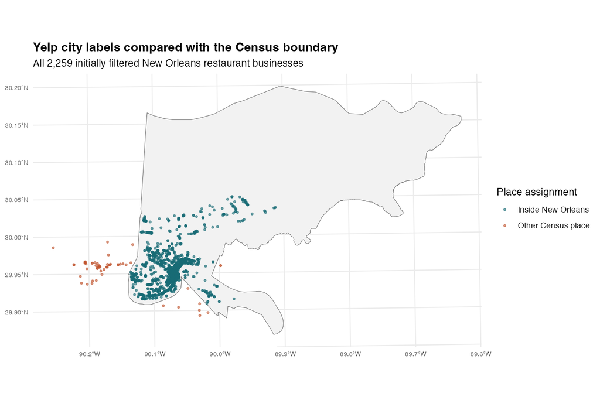

Census boundary and all initially filtered restaurant locations

### Step 6: ZCTAs compared with wards

Restaurant coordinates are transformed from longitude/latitude (EPSG:4326) to NAD83 / Louisiana South in metres (EPSG:26982). Polygon validity is repaired before spatial joins. The same 656 city-contained locations are joined to each system with st_within. No nearest-area assignment or snapping is applied. The joins are checked for duplicated businesses and boundary-touching points.

| System | Populated areas | Assigned | Unmatched | Min count* | Max count |
| --- | --- | --- | --- | --- | --- |
| ZCTA | 17 | 656 | 0 | 2 | 213 |
| Ward | 17 | 654 | 2 | 5 | 116 |

*Minimum among populated areas. Of 35 ZCTA polygons intersecting the city, 18 contain no selected city restaurants and five populated ZCTAs contain fewer than 10. All 17 wards contain selected restaurants, and only Ward 16 has fewer than 10 (five). Empty and small areas are retained in the exported summaries. Empty areas have no rating, not a rating of zero.

The two unmatched ward locations are Felix’s Restaurant & Oyster Bar and Brisbi’s Lakefront Restaurant & Bar, both at 7400 Lakeshore Drive. They fall inside the Census city but approximately 16.3 and 13.4 metres outside the nearest Ward 4 polygon. These shoreline discrepancies could reflect coordinate or boundary precision; they are not corrected without further evidence. Both receive ZCTA 70124. They remain in the city dataset and are omitted only from ward-level aggregates.

[Complete comparison](https://github.com/Brandonlee-2002/Yelp_new_orleans/blob/main/data/analysis/geography_comparison.csv) · [Unmatched ward locations](https://github.com/Brandonlee-2002/Yelp_new_orleans/blob/main/data/analysis/ward_unmatched.csv)

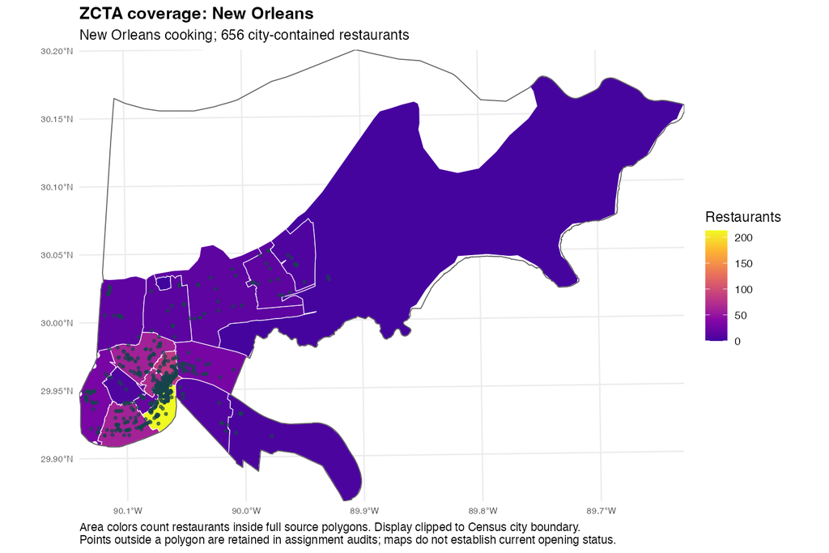

ZCTA boundaries and selected restaurant locations across New Orleans

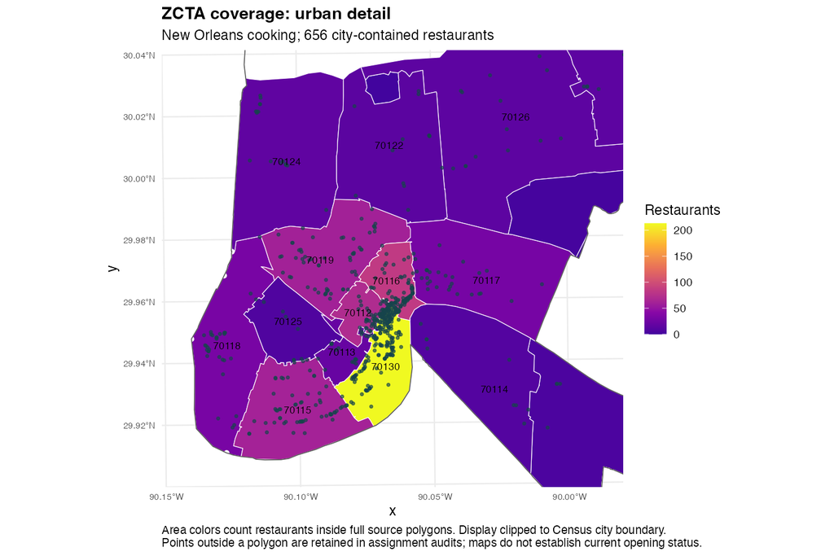

ZCTA boundaries and restaurant locations in the urban core

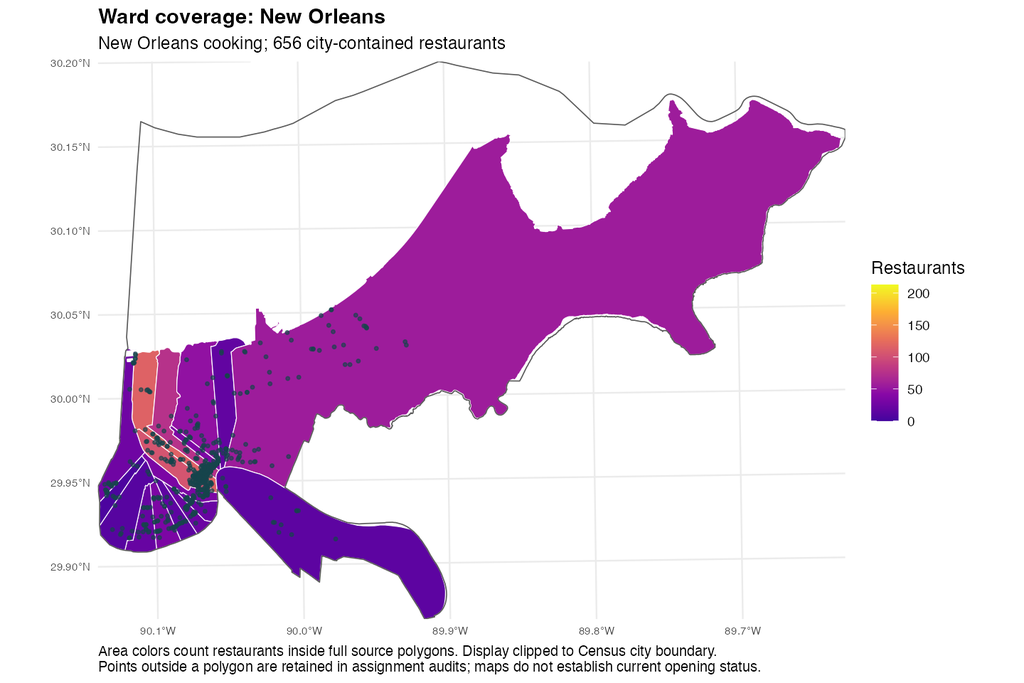

Ward boundaries and selected restaurant locations across New Orleans

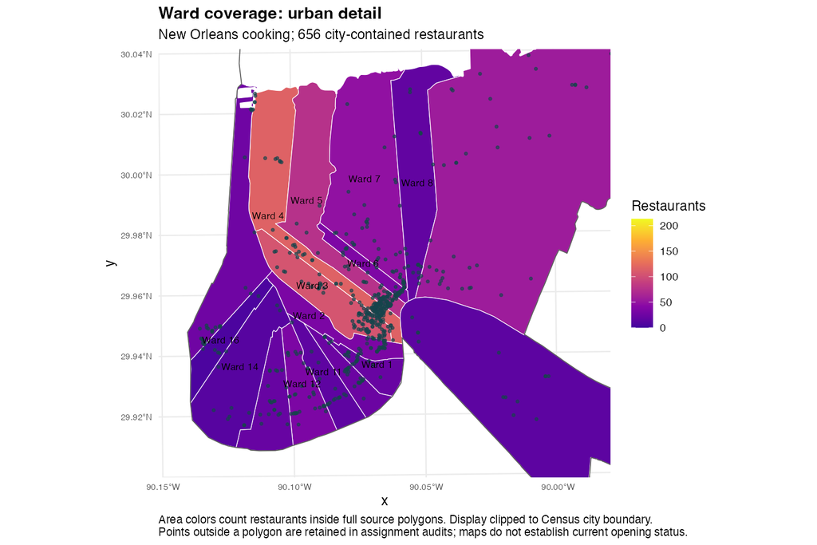

Ward boundaries and restaurant locations in the urban core

The full-city maps preserve the geographic context; the urban-detail panels make the dense restaurant cluster readable. Colors describe counts in the full source areas, using only city-contained restaurants. Displayed boundaries are clipped to the Census city. ZCTAs are Census approximations of postal service areas, not neighborhoods; wards are the City’s numbered divisions, not neighborhood labels.

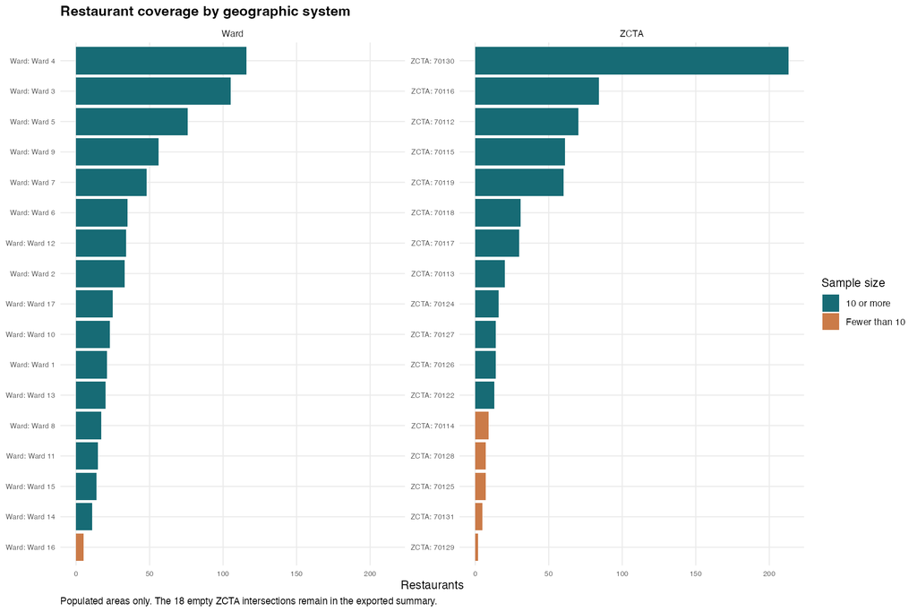

Restaurant counts by ZCTA and ward

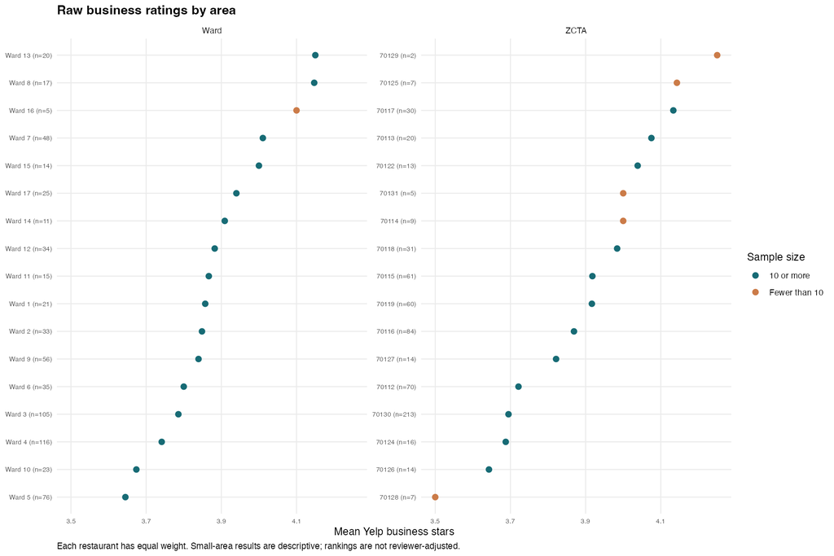

Average raw business ratings by ZCTA and ward, with sample sizes

#### Main geographic choice: wards

Use **wards** for the main area comparison and keep ZCTAs as the sensitivity comparison. Wards divide this restaurant pool more evenly: the median populated-area count is 25 versus 16 for ZCTAs, the largest ward contains 116 restaurants versus 213 in the largest ZCTA, and only one ward has fewer than 10 restaurants versus five populated ZCTAs. Both systems offer 17 populated areas. Wards therefore reduce the number of very small samples while retaining city-specific numbered areas that can be shown clearly on maps. This choice follows coverage and sample-size evidence, not which system yields a higher rating.

The tradeoffs are the two unmatched lakefront points, the need to explain ward numbers to visitors, and broad wards that can hide variation within an area. Ward 16’s five restaurants are too few for a strong area-level recommendation; its rating remains descriptive. ZCTAs offer familiar postal-style identifiers and complete assignment of the city subset, so both sets of results remain available. Restaurant counts measure selection, not density per square kilometre or travel convenience.

#### Area summaries

Means below give each restaurant equal weight, not each review. Review totals indicate evidence volume but do not establish independence or uncertainty. These are historical raw-rating summaries; the final reviewer-adjusted comparison is presented in the main report.

**Wards**

| Area | Restaurants | Marked open | Mean stars | Reviews |
| --- | --- | --- | --- | --- |
| Ward 4 | 116 | 74 | 3.74 | 84,332 |
| Ward 3 | 105 | 69 | 3.79 | 41,454 |
| Ward 5 | 76 | 47 | 3.64 | 39,927 |
| Ward 9 | 56 | 42 | 3.84 | 6,248 |
| Ward 7 | 48 | 34 | 4.01 | 7,191 |
| Ward 6 | 35 | 21 | 3.80 | 10,634 |
| Ward 12 | 34 | 25 | 3.88 | 9,798 |
| Ward 2 | 33 | 17 | 3.85 | 14,007 |
| Ward 17 | 25 | 14 | 3.94 | 6,338 |
| Ward 10 | 23 | 13 | 3.67 | 5,209 |
| Ward 1 | 21 | 13 | 3.86 | 3,904 |
| Ward 13 | 20 | 12 | 4.15 | 4,412 |
| Ward 8 | 17 | 10 | 4.15 | 3,606 |
| Ward 11 | 15 | 11 | 3.87 | 8,925 |
| Ward 15 | 14 | 10 | 4.00 | 413 |
| Ward 14 | 11 | 7 | 3.91 | 1,324 |
| Ward 16 | 5 | 3 | 4.10 | 832 |

**ZCTAs**

| Area | Restaurants | Marked open | Mean stars | Reviews |
| --- | --- | --- | --- | --- |
| 70130 | 213 | 130 | 3.69 | 133,630 |
| 70116 | 84 | 47 | 3.87 | 28,730 |
| 70112 | 70 | 45 | 3.72 | 26,367 |
| 70115 | 61 | 42 | 3.92 | 17,071 |
| 70119 | 60 | 44 | 3.92 | 18,065 |
| 70118 | 31 | 18 | 3.98 | 7,280 |
| 70117 | 30 | 18 | 4.13 | 7,651 |
| 70113 | 20 | 15 | 4.08 | 4,253 |
| 70124 | 16 | 11 | 3.69 | 2,553 |
| 70126 | 14 | 11 | 3.64 | 450 |
| 70127 | 14 | 10 | 3.82 | 705 |
| 70122 | 13 | 10 | 4.04 | 968 |
| 70114 | 9 | 6 | 4.00 | 281 |
| 70128 | 7 | 7 | 3.50 | 398 |
| 70125 | 7 | 3 | 4.14 | 407 |
| 70131 | 5 | 4 | 4.00 | 132 |
| 70129 | 2 | 2 | 4.25 | 61 |

Ward 4 has the most qualifying restaurants (116); Ward 13 has the highest mean business rating among wards with at least 10 restaurants (4.15, n=20), narrowly ahead of Ward 8 (4.147, n=17). This is not enough to declare a final best area. ZCTA 70130 has the largest selection (213), while 70117 leads populated ZCTAs with at least 10 restaurants in raw mean stars (4.13, n=30). The main report checks these raw patterns against reviewer adjustment and final eligibility rules.

#### Boundary sources and time limitations

Census boundaries: [2020 TIGER/Line place files](https://www.census.gov/geographies/mapping-files/time-series/geo/tiger-line-file.html) and [2020 cartographic ZCTA boundaries](https://www.census.gov/geographies/mapping-files/time-series/geo/cartographic-boundary.html), obtained with tigris. Wards: [City of New Orleans Enterprise GIS, Administrative Layers, Wards layer 3](https://maps.nola.gov/server/rest/services/Administrative/Administrative_Layers/MapServer/3), downloaded October 29, 2026. The ward service does not state a historical effective date; it is a saved current-service snapshot, not verified 2020 ward geometry. Yelp reviews span 2005–2022, so neither boundary set proves which area applied at every review date. Saved boundaries, source metadata, and checksums support reproduction; no demographic or causal claims are made.

## Reproducibility and source files

The main packages are `jsonlite` for streamed JSON parsing, `dplyr` for grouped summaries, `ggplot2` for charts, `sf` for spatial joins and maps, `ggrepel` for readable labels, `renv` for dependency locking, and Quarto for rendered reports. Native `sf` dependencies may still require GDAL, GEOS, and PROJ on systems without suitable binaries.

The final ranking also includes a fixed-seed bootstrap stability diagnostic. It resamples eligible reviews within each restaurant for 1,000 replicates while holding reviewer baselines, restaurant eligibility, and area membership fixed. This is deliberately described as a stability analysis rather than a claim of population-level statistical inference.

## Methods defense

The primary reviewer adjustment now uses a leave-one-review-out baseline: a review is compared with the reviewer’s mean score across their other reviews. This avoids using the target review to define its own reference point. The Yelp extract contains repeated `(user_id, business_id)` pairs, so the project audits those pairs and uses true leave-one-review-out arithmetic rather than assuming one review per reviewer-business pair.

The five-review reviewer threshold, 50-review restaurant minimum, 20 eligible-reviewer minimum, and ten-restaurant ward minimum remain the primary specification. These are evidence-coverage rules, not claims of statistical significance. The sensitivity output separates reviewer selection from adjustment, includes legacy in-sample baselines, closed businesses, strict core-cuisine scope, shrinkage, and lower-confidence-bound rankings.

The ranking uncertainty analysis uses 1,000 fixed-seed bootstrap replicates, resampling eligible reviews within each restaurant and reporting rank percentiles and top-15 inclusion probabilities. Ward uncertainty additionally reports restaurant-level bootstrap intervals and a max-selection permutation test. Split-half reliability compares how consistently raw and adjusted restaurant scores reproduce across random halves; if adjustment is not more reliable, that result is retained as a limitation rather than treated as evidence in its favor. An `lme4` mixed-model cross-check is optional and is explicitly marked skipped when the package is unavailable.

The broad category theme remains the headline scope, while a strict core-cuisine sensitivity excludes businesses that match only Seafood. This is important because Yelp labels are operational categories, not authenticity evidence. Area language is intentionally limited to “highest mean among rankable wards” when the permutation test does not distinguish the winner.

Follow the [repository README](https://github.com/Brandonlee-2002/Yelp_new_orleans) to restore the locked R environment, run the scripts, and render all four pages. Final reviewer normalization, eligibility, score definitions, and sensitivity results appear in the full results.

- [Import](https://github.com/Brandonlee-2002/Yelp_new_orleans/blob/main/R/import.R) · [Cleaning](https://github.com/Brandonlee-2002/Yelp_new_orleans/blob/main/R/clean.R)
- [Initial analysis](https://github.com/Brandonlee-2002/Yelp_new_orleans/blob/main/R/analysis.R) · [Geographic analysis](https://github.com/Brandonlee-2002/Yelp_new_orleans/blob/main/R/geography.R)
- [Final rankings](https://github.com/Brandonlee-2002/Yelp_new_orleans/blob/main/R/rankings.R) · [Boundary provenance](https://github.com/Brandonlee-2002/Yelp_new_orleans/blob/main/data/boundaries/README.md)
- [Environment restore checks](https://github.com/Brandonlee-2002/Yelp_new_orleans/blob/main/data/analysis/environment_restore_check.csv)

Brandon Lee · Methods and reproducibility · October 29, 2026